# Getting comfortable in ggplot and Tableau

Just messing around with basic graphs using ggplot2 and Tableau…and markdown w/ knitr

### Load in data + packages

```r
library("ggplot2", lib.loc="~/R/win-library/3.2")
library("dplyr", lib.loc="~/R/win-library/3.2")
library("reshape2", lib.loc="~/R/win-library/3.2")
library("readxl", lib.loc="~/R/win-library/3.2")
Intel.1998 <- read.csv("~/HW-1-Data/Intel-1998.csv")
Experiment <- read.csv("~/HW-1-Data/PerceptionExperiment2007-2015Fall.csv")
babydata <- read_excel("~/HW-1-Data/InfantData.xlsx")
```

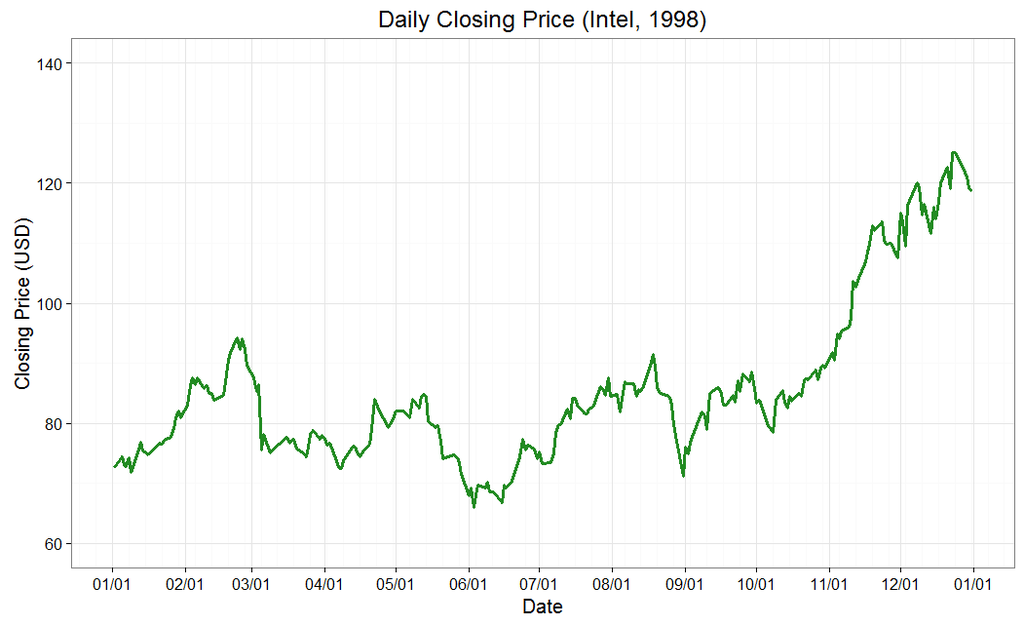

```r
#the variables we're interested in are Date and Close
#remember the core syntax of ggplot?
class(Intel.1998$Date)
Intel.1998$Date <- as.Date(Intel.1998$Date, "%m/%d/%Y")

#set up our plot
daily.close <- ggplot(data = Intel.1998, aes(x = Date, y = Close)) + geom_line(color = "forestgreen ", size = 1.25) +
  theme_bw(20) + labs(title = "Daily Closing Price (Intel, 1998)", y="Closing Price (USD)") +
  scale_x_date(date_breaks='1 months', date_labels = '%m/%d', date_minor_breaks="7 days") +
  scale_y_continuous(limits = c(60,140), breaks=seq(60,140,20), minor_breaks = seq(60,140,10))

daily.close
```

### Exercise 2: Bar graph

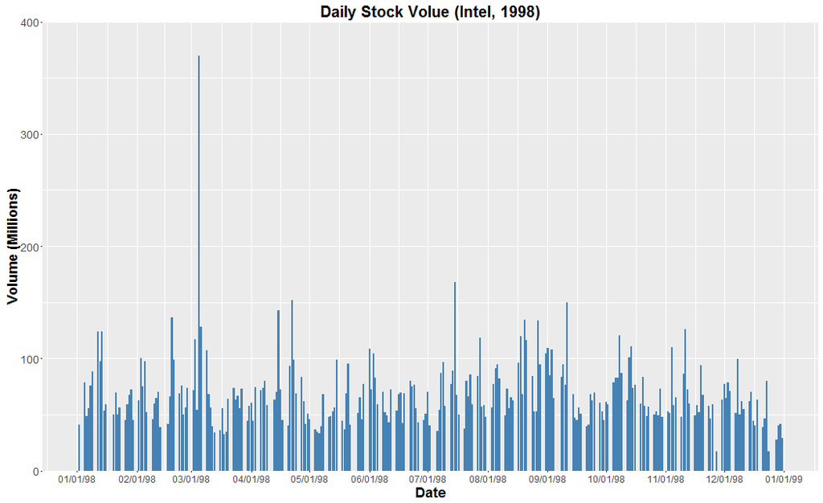

```r
daily.volume <- ggplot(data = Intel.1998, aes(x=Date, y=Volume/1000000)) +
  geom_bar(stat="identity", fill="steelblue") + labs(title = "Daily Stock Volume (Intel, 1998)", y = "Volume (Millions)") +
  theme(plot.title = element_text(face="bold", size=20)) +
  theme(axis.title = element_text(face="bold", size=18)) +
  theme(axis.text.x = element_text(size=12)) + theme(axis.text.y = element_text(size= 14)) +
  scale_x_date(date_breaks='1 months', date_labels = '%m/%d/%y') +
  scale_y_continuous(expand = c(0,0), limits = c(0,400), breaks=seq(0,400,100), minor_breaks = seq(0,400,50))

daily.volume
```

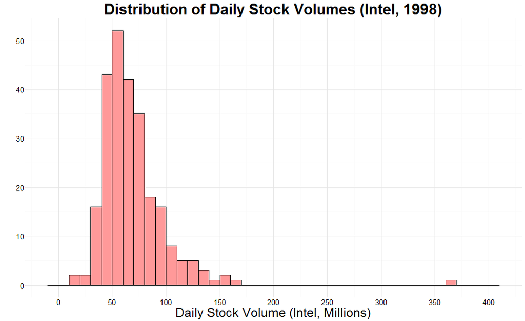

```r
#histogram of daily stock volume

daily.volume.hist <- ggplot(data = Intel.1998, aes(Volume/1000000)) + geom_histogram(color = 'black', fill='#FF9999', binwidth = 10) +
  theme_minimal() + labs(title = "Distribution of Daily Stock Volumes (Intel, 1998)",
                         x = "Daily Stock Volume (Intel, Millions)", y = "") +
  theme(plot.title=element_text(size=30, face="bold"), axis.text.x=element_text(size=15), axis.text.y=element_text(size=15), axis.title.x=element_text(size=25), axis.title.y=element_text(size=25)) +
  expand_limits(x=c(0,400)) + scale_x_continuous(breaks=seq(0,400,50))

daily.volume.hist
```

### Exercise 4: Scatterplot

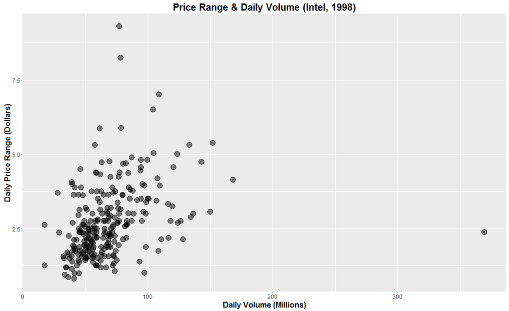

```r
#create a scatterplot of volume on x-axis and price range (calc'd column of high-low) as yaxis

#create price range column
Intel.1998$PriceRange <- Intel.1998$High - Intel.1998$Low

#create scatterplot
pricerange.scatter <- ggplot(data = Intel.1998, aes(x = Volume/1000000, y = PriceRange)) + geom_jitter(size = 5.5, color = "black", alpha=1/2) +
  labs(title = "Price Range & Daily Volume (Intel, 1998)", x = "Daily Volume (Millions)", y = "Daily Price Range (Dollars)") +
  theme(plot.title = element_text(size = 20, face="bold"),
        axis.title.x = element_text(size = 16, face="bold"), axis.text.x = element_text(size=12),
        axis.title.y = element_text(size=16, face="bold"), axis.text.y = element_text(size=12))
pricerange.scatter
```

### Exercise 5: Histogram

Uses perception experiment data *A histogram of the overall distribution of deviations.*

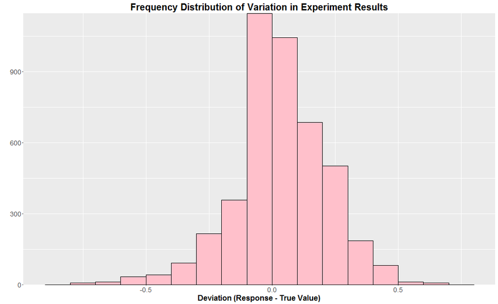

```r
#using experiment file make a histogram of the distribution of deviations (deviations being a calc'd column of Response - TrueValue)
Experiment$Deviation <- Experiment$Response - Experiment$TrueValue

deviation.hist <- ggplot(data = Experiment, aes(Experiment$Deviation)) + geom_histogram(binwidth = .1, color="black", fill="pink") + labs(title = "Frequency Distribution of Variation in Experiment Results", x = "Deviation (Response - True Value)", y = "") +
  theme(plot.title = element_text(size = 20, face="bold"),
        axis.title.x = element_text(size = 16, face="bold"), axis.text.x = element_text(size=14),
        axis.text.y = element_text(size=14)) +
  scale_y_continuous(expand = c(0,0))
deviation.hist
```

### Exercise 6: Bar graph

Uses perception experiment data *A bar graph of the median Deviations by* *Test . do not subdivide by the display or the trial. Order the x-axis to make the display as clear as possible.*

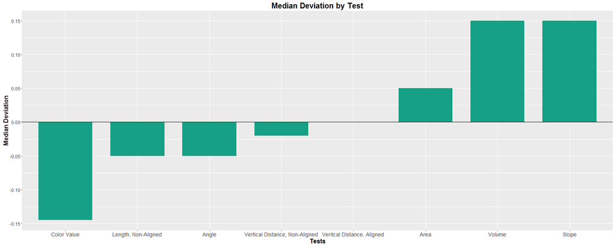

```r
#make a bar graph of the median deviations by test

med.dev.by.test <- group_by(Experiment, Test)
med.dev.by.test <- summarize(med.dev.by.test, median.dev = median(Deviation))

head(med.dev.by.test)

dev.by.test.chart <- ggplot(data = med.dev.by.test, aes(x = reorder(Test, median.dev), y = median.dev)) + geom_bar(stat = 'identity', fill="#16a085", width = .75) +
  geom_hline(yintercept = 0) +
  labs(title = "Median Deviation by Test",x = "Tests", y = "Median Deviation") +
  theme(plot.title = element_text(size = 20, face="bold"),
        axis.title.x = element_text(size = 16, face="bold"), axis.text.x = element_text(size=14),
        axis.title.y = element_text(size=16, face="bold"), axis.text.y = element_text(size=12)) +
  scale_y_continuous(breaks = seq(-0.2,0.2,.05))
dev.by.test.chart
```

### Exercise 7: Bar graph

Uses perception experiment data *A bar graph of the standard deviation of the “Deviations”. Remember that this measures the spread of how widely subjects varied in their responses. Again, order the x-axis to make the graph clear.*

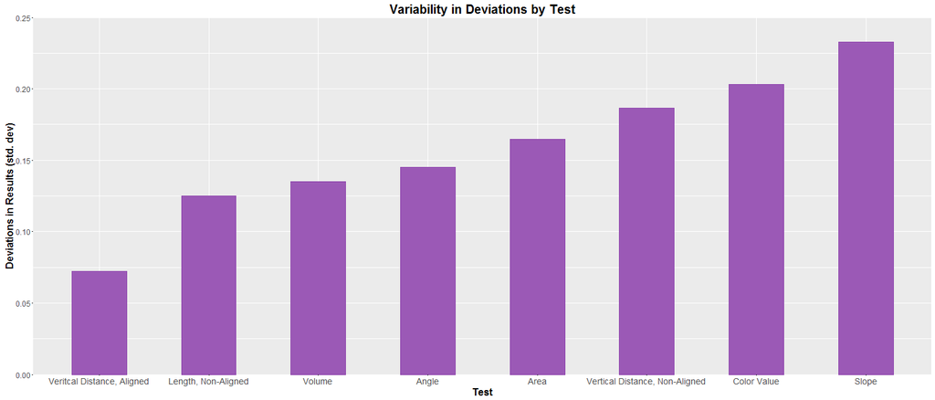

```r
#bar graph of standard devs of "Deviations"

grouped.by.test <- group_by(Experiment, Test)
middata <- summarize(grouped.by.test, sd.dev = sd(Deviation))

newdata <- middata[order(middata$sd.dev),]
newdata

plot.devs <- ggplot(data = newdata, aes(x = reorder(newdata$Test, newdata$sd.dev), y = newdata$sd.dev)) +
  geom_bar(stat='identity', color="#8e44ad", fill="#9b59b6", width=.5) +
  labs(title="Variability in Deviations by Test", x="Test", y="Deviations in Results (std. dev)") +
  theme(plot.title = element_text(size = 20, face="bold"),
        axis.title.x = element_text(size = 16, face="bold"), axis.text.x = element_text(size=14),
        axis.title.y = element_text(size = 16, face="bold"), axis.text.y = element_text(size=12)) +
  scale_y_continuous(expand=c(0,0), limits = c(0,.25))

plot.devs
```

### Exercise 8: Bar graph

Uses perception experiment data *Create a new field called “absoluteDeviation” by computing the absolute value of the Deviation field you* *created. Then do the same as in b) with the absolute deviation. Again, do not* *keep the default order (alphabetical) of the x-axis.*

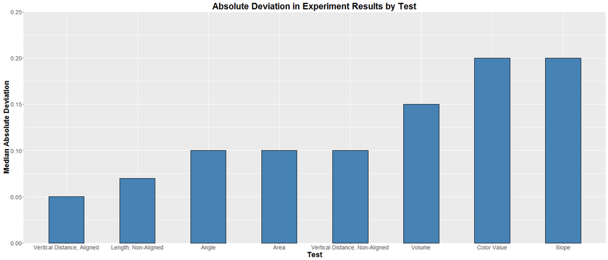

```r
#create a bar chart of the media absolute value of deviation by experiment

head(Experiment)

#so we want to calculate a new column, abs value of Deviation

Experiment$abs.Deviation <- abs(Experiment$Deviation)
head(Experiment)

#now we want to group by test type
grouped.by.test <- group_by(Experiment, Test)
grouped.dev.summary <- summarise(grouped.by.test, median(abs.Deviation))

head(grouped.dev.summary)
grouped.dev.summary$`median(abs.Deviation)`

#data is grouped how we want, but not sorted
abs.dev.barplot <- ggplot(data=grouped.dev.summary, aes(x=reorder(Test, grouped.dev.summary$`median(abs.Deviation)`), y=grouped.dev.summary$`median(abs.Deviation)`)) +
  geom_bar(stat='identity', fill = "steelblue", color = "black", width=.5) + labs(title="Absolute Deviation in Experiment Results by Test", x = "Test", y = "Median Absolute Deviation") +
  theme(plot.title = element_text(face="bold", size=rel(2)),
  axis.title = element_text(face="bold", size=18),
  axis.text.x = element_text(size=14), axis.text.y = element_text(size= 14)) +
  scale_y_continuous(expand=c(0,0), limits = c(0,.25))

abs.dev.barplot
```

### Exercise 9: Scatterplot

Uses baby data *Graph the data as a scatter plot of length on the x-axis and weight on the y-axis. Differentiate in the plot between boys and girls, but graph both on the same plot.*

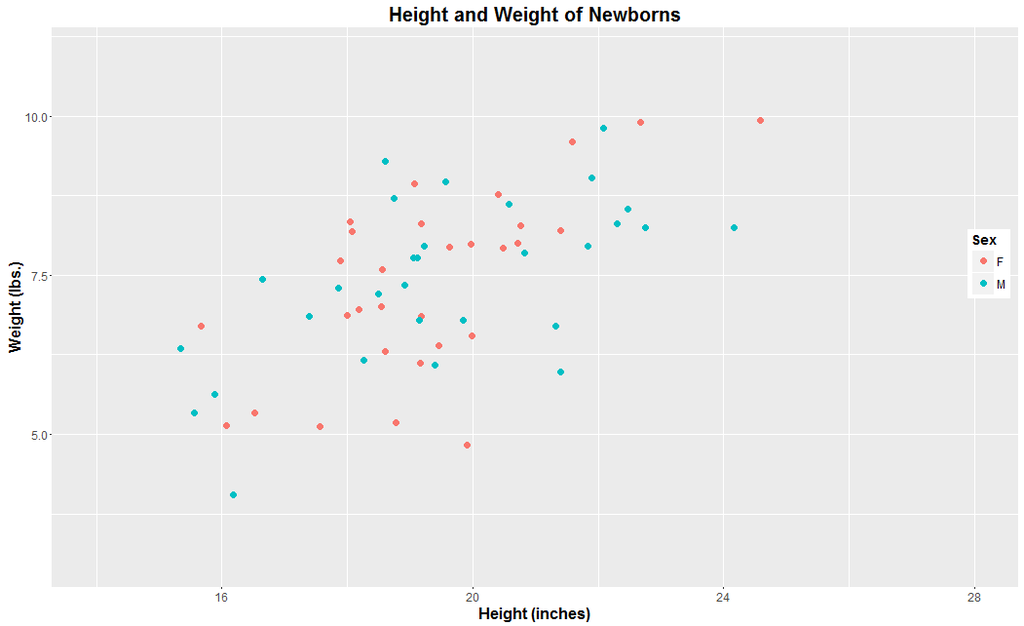

```r
#using babies data, graph scatterplot of length on x axis and weight on y axis. boys/girls on same graph but distinguished (color)
library(readxl)

height.weight.gendered.plot <- ggplot(data= babydata, aes(x = babydata$`Height in`, y = babydata$`Weight lbs`)) + geom_point(aes(color = babydata$Sex), size=3) +
  labs(title="Height and Weight of Newborns", x="Height (inches)", y="Weight (lbs.)")+
  theme(plot.title = element_text(size = 20, face="bold"),
        axis.title.x = element_text(size = 16, face="bold"), axis.text.x = element_text(size=12),
        axis.title.y = element_text(size = 16, face="bold"), axis.text.y = element_text(size=12),
        legend.title = element_text(size=14, face="bold"),legend.text = element_text(size=12),
        legend.justification=c(1,0), legend.position=c(1,0.5)) +
  expand_limits(x= c(14,28), y=c(3,11)) + scale_x_continuous(minor_breaks=seq(14,28,2)) +
  scale_color_discrete(name = "Sex")

height.weight.gendered.plot
```

### Exercise 10: Scatterplot w/ trendline

Uses baby data *Then create another version of the* *graph that has separate trend lines for the two populations on the graph.* *Adjust both the line and data point weight and color to make the scatter* *plot and trend lines stand.*

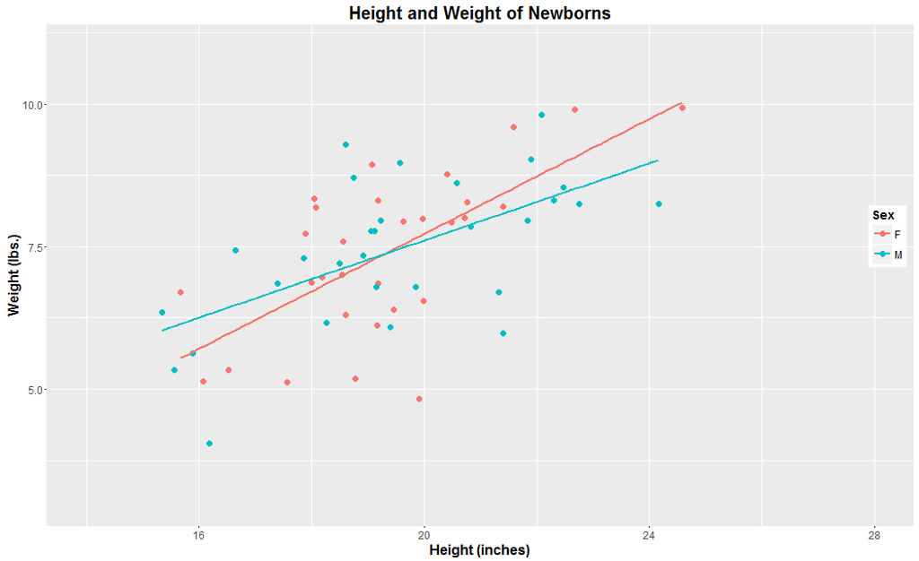

```r
height.weight.gendered.plottrend <- ggplot(data= babydata, aes(x = babydata$`Height in`, y = babydata$`Weight lbs`, colour = babydata$Sex)) + geom_point(size=3) +
  geom_smooth(method = 'lm', formula=y~x, se=FALSE, level=.95, size=.75) +
  labs(title="Height and Weight of Newborns", x="Height (inches)", y="Weight (lbs.)")+
  theme(plot.title = element_text(size = 20, face="bold"),
        axis.title.x = element_text(size = 16, face="bold"), axis.text.x = element_text(size=12),
        axis.title.y = element_text(size = 16, face="bold"), axis.text.y = element_text(size=12),
        legend.title = element_text(size=14, face="bold"),legend.text = element_text(size=12),
        legend.justification=c(1,0), legend.position=c(1,0.5)) +
  expand_limits(x= c(14,28), y=c(3,11)) + scale_x_continuous(minor_breaks=seq(14,28,2)) +
  scale_color_discrete(name = "Sex")
height.weight.gendered.plottrend
```

### Exercise 11: Tree map (Tableau)

Uses dataset of car makes/models *A tree-map based on price with a main subdivision from the make of the car and a minor subdivision based on the model. Hint: hierarchies may be useful for this.*

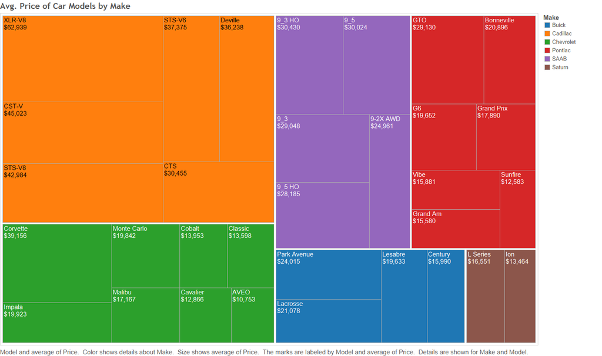

### Exercise 12: Bubble chart (Tableau)

Uses dataset of car makes/models *A bubble chart of the same type*

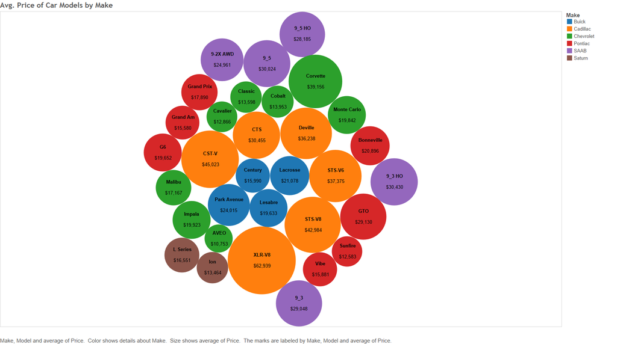

The biggest difference I see between the two designs is that a tree map puts more emphasis on the makes, while bubble graph puts more emphasis on the model and price. This is, in my opinion, because the bubble graph has separation between the different values, whereas a tree graph makes them seem part of whole, then as different makes, then size, then model. That difference in priority is what my eye goes to.

### Exercise 13: Line graph (Tableau)

Uses dataset of population in Montana reservations *Graphs the population growth over the years for the individual reservations.*

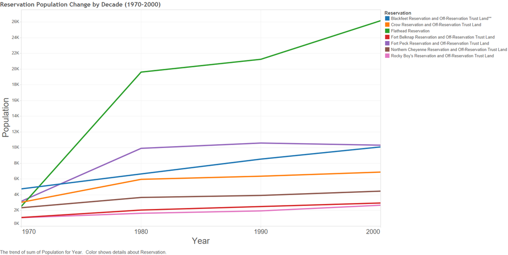

### Exercise 14: Stacked bar chart (Tableau)

Uses dataset of population in Montana reservations *Graphs the total reservation population subdivided among the different reservations for each year.*

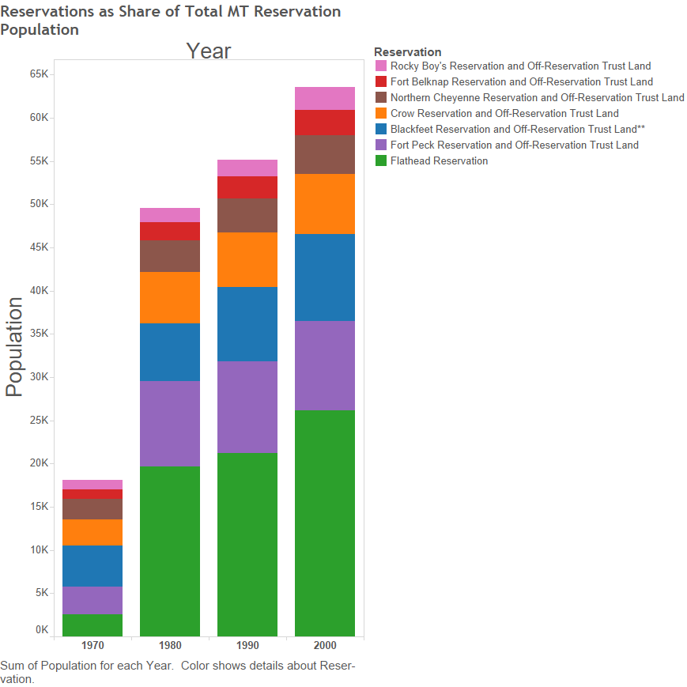

### Exercise 15: Box-and-whisker plot (Tableau)

Uses dataset of population in Montana reservations *Graphs the population distribution for each reservation with a box-and-whisker plot.*

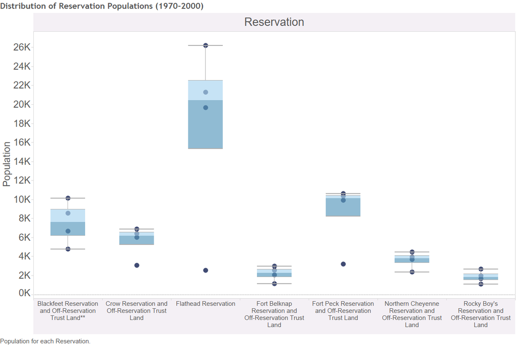